# Coursework 2

Marco Visentin, CID: 01928255

```python
#import modules

import sys, os, time
import numpy as np
import scipy.io as io
import matplotlib.pyplot as plt
import pandas as pd
import seaborn as sns
import networkx as nx
import math
```

```python
# Load dataset

datadir = 'data/dataset3_m62/'
trackdata = io.loadmat(datadir+'downTrackdata.mat')
phi = trackdata['phi']; x = trackdata['x']; y = trackdata['y']; r=trackdata['r'];
speed = trackdata['speed']; t = trackdata['time'];
spikedata = io.loadmat(datadir+'spikes.mat')
spikes = spikedata['spikes']
params = spikedata['params']
fluodata = io.loadmat(datadir+'fissa_output.mat')
dfonf = fluodata['ddf_f']
```

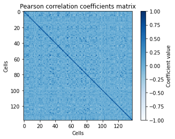

```python
# Plot the matrix of Pearson correlation coefficients between the calcium fluorescence time series from each cell

df = pd.DataFrame(dfonf.T)                                  # from 2D array to DataFrame
PCM_ = df.corr()                                            # Pearson correlation among columns in the DataFrame
PCM = PCM_.to_numpy()                                       # from DataFrame to 2D array
plt.imshow(PCM, cmap='Blues' )                              # colorbar for an easier interpretation
plt.clim(-1,1)                                              # range from -1 to 1
plt.colorbar(label='Coefficient value')
plt.title('Pearson correlation coefficients matrix')
plt.xlabel('Cells')
plt.ylabel('Cells')
plt.show()
```

The Pearson correlation coefficient measures the linear correlation between two cells' time series. Each time series carries the values of fluorecence over time, which is a measure of the local calcium concentration. As a neuron fires, calcium concentration, and thus fluorecence, increase rapidly. As expected, the plot shows perfect correlation between the values of same cell. Also, most of the neurons' time series are scorrelated or weakly correlated, although few of them have high positive correlation coefficient, showing similar behaviour over time as pointed by the dark blue spots in the plot.

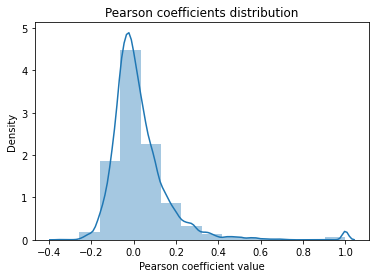

```python
# Plot the distribution coefficient

ax = sns.distplot(PCM,bins = 14, kde = True)     # histogram plotted together with kernel density estimation
ax.set(xlabel='Pearson coefficient value', ylabel = 'Density' )
ax.set_title ('Pearson coefficients distribution')
plt.show()
```

The plot shows the histogram of the distribution of Pearson correlation coefficients among the 138 neurons analyzed and the kernel density estimation, which produces a smooth curve for the visualisation of the distribution. As pointed out before, the peak around zero highlights that there is no linear relationship between most of them and only few of them show a strong positive correlation. The peak in Pearson coefficient value = 1 is due to the perfect correlation between equal time series belonging to the same neuron. Negative correlation is always weak.

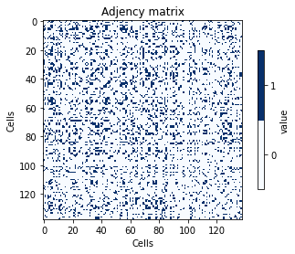

```python
# Plot adjency matrix

p = np.percentile(PCM,80)                           # 80th percentile of the distribution calculation
N = np.shape(PCM)[1]
for i in range(0,N):
    for j in range(0,N):
        if i==j:
            PCM[i,j] = 0                             # 0 in the main diagonal. Self-edges don't allowed
        if PCM[i,j] > p:
            PCM[i,j] = 1                             # 1 if the Pearson coefficient exceeds the 80th percentile
        else:
            PCM[i,j] = 0                             # 0 if not
plt.figure()
plt.imshow(PCM, cmap=plt.cm.get_cmap('Blues', 2))
plt.colorbar(ticks = [1,0], shrink = 0.7, label = "value")
plt.clim(-0.5,1.5)                                   # 1 and 0 are centered in the colorbar
plt.title('Adjency matrix')
plt.xlabel('Cells')
plt.ylabel('Cells')
plt.show()
```

The adjency matrix indicates whether two nodes i,j are adjacent (A$_{ij}$ = 1) or not (A$_{ij}$ = 0) in the graph. According to the model adopted to build the network, each neuron correspond to one node and it is undirectionally connected (adjacent) to another one only if their Pearson correlation coefficient is above the 80$^{th}$ percentile of the distribution. The network is not weighted.

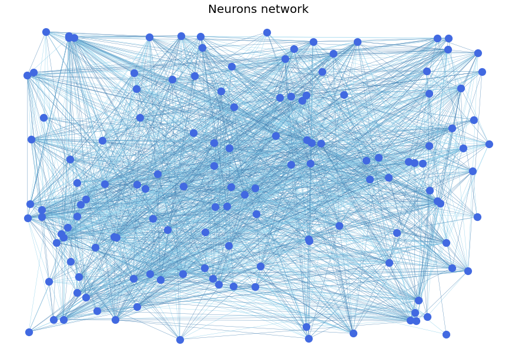

```python
#Plot the graph with another method

fig =plt.figure(figsize = (12,8))
H = nx.from_numpy_matrix(PCM)                    # get the graph from the adjency matrix
kwds = { 'node_size' : 150,
         'node_color' : 'royalblue',
         'width': 0.4,
         'edge_color': {'skyblue','steelblue'}
        }
nx.draw_random(H,**kwds)                         # draw it randomly
plt.title('Neurons network', fontsize = 20)
plt.show()
```

This is another visualization method for the neurons network. Each blue spot represents a node (neuron) and each line an undirected edge. Two nodes connected by an edge are adjacent. Edges have different colors but only to be easier to see, they are not weighted.

```python
K = np.array(H.degree)                                   # K is a 138x2 matrix (column1 = node number, column2 = degree)
k = sum(K[:,1])/N                                        # average degree for the network described by the adjency matrix
C = (nx.average_clustering(H))                           # average local cluster coefficient for the network described by the adjency matrix

# to have a finite diameter it's necessary to have a connected network (if not it's infinite)
# find out if there are unconnected nodes

m = 0
for i in range(0,N):
    if (PCM[i,:] == np.zeros(N)).all():                  # look for the rows of all zeros
        PCM_ = np.delete(PCM, i,0)                       # delete both row and column of the unconnected nodes
        PCM_1 = np.delete(PCM_,i,1)
        m = m+1                                          # number of unconnected nodes

#  Since we want to compare the network to a Small-World network it is necessary to work on the actual network without the eventual unconnected nodes

if m != 0:
    H1 = nx.from_numpy_matrix(PCM_1)                     # graph with the new adjency matrix
    K_ = np.array(H1.degree)
    k_ = sum(K_[:,1])/(PCM_1.shape[0])                   # new average degree
    C_ = (nx.average_clustering(H1))                     # new average clustering
    d_ = nx.algorithms.distance_measures.diameter(H1)    # new diameter
    print ('Number of unconnected nodes: ', m)
    print ('Average degree of the original graph and of the connected graph, respectively:',k, ',' ,k_)
    print ('Average clustering of the original graph and of the connected graph, respectively:',C,',',C_)
    print ('Diameter of the original graph and of the connected graph, respectively: infinite,', d_)

# if the graph is connected we can work on that

else:
    d = nx.algorithms.distance_measures.diameter(H)      # diameter
    print ('Average degree:',k)
    print ('Average clustering:',C)
    print ('Diameter:',d)
```

```
Number of unconnected nodes:  1
Average degree of the original graph and of the connected graph, respectively: 26.594202898550726 , 26.78832116788321
Average clustering of the original graph and of the connected graph, respectively: 0.477392010026368 , 0.4808766232382393
Diameter of the original graph and of the connected graph, respectively: infinite, 4
```

The graph described by the adjency matrix is not connected because there is a node with degree = $0$. The average degree of the network is $26.594$ while the average cluster coefficient is $0.477$. The average cluster coefficient is higher than the one we could expect from a random network. Erdos-Renyi represents a good method to model a random network and the average cluster coefficient $C$ can be calculated as $C = q$ where $q = {\overline k}/ (N-1)$ if self-edges are not allowed. Since ${\overline k} = 26.594$ the expected average cluster coefficient from a random network would be $C_{random} = 0.194$ which is less than a half of the one of the neurons network. Since the graph described by the adjency matrix is not connected the diameter $d$ is infinite. If the unconnected node is deleted from the adjency matrix $d = 4$. The average degree and the average cluster coefficient of the connected network are printed above: the average cluster coefficient is still more than two times of the one of a random network ($C = 0.481$, $C_{random} = 0.196$).

A Small World network is a sparse, highly clustered type of graph where $d \propto logN$. A network is defined sparse when ${\overline k}>>N$. Since the original network has an infinite diameter it cannot be defined as a Small World, so considerations will be made on the connected graph.

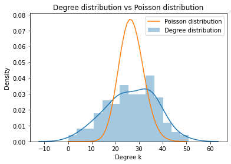

```python
def poisson(k,degree):
    return k**degree * math.exp(-1*k)/math.factorial(degree)  #poisson distribution formula with mean k(graph's average degree)

# Plot the degree distribution for the network
plt.figure(2)
ax = sns.distplot(K[:,1],bins = 14, kde = True, label = 'Degree distribution')
ax.set(xlabel='Degree k', ylabel='Density')
ax.set_title ('Degree distribution vs Poisson distribution')


#Overlay it with the poisson distribution
x = np.array(range(0,max(K_[:,1]),1))
poi = []
for n in range(max(K_[:,1])):
    poi.append(poisson(k_,n))
plt.plot(x,poi, label = 'Poisson distribution')
plt.legend()
plt.show()
```

The Poisson distribution plotted approximates the degree distribution of a random network modelled as a Erdos-Renyi network with average degree equal to $\overline k$. This is characterized by a sharp peak in $k = \overline k$ and a rapid drop off beyond this point. The degree distribution of the neurons network does not have a peak centered in k = $\overline k$ and shows an over-representation of highly connected nodes: this is typical of scale-free networks. Although, a scale-free network, according to its classic definition, should be characterized by a power-law distribution $p(k) = k^{\alpha}$ (generally $-2<\alpha<-3$), but it seems to only govern the distribution's upper tail.

The idea that the scale-free pattern may only hold for the largest degrees is an auxiliary hypotheses with which the definition is often modified (Broido & Clauset, 2019). Hence, keeping this in mind, this network can be described ad a Free-scale network.

References

Anna D. Broido, Aaron Clauset, (04 March 2019), Scale-free networks are rare, Nature Communications, Avaliable from: https://www.nature.com/articles/s41467-019-08746-5